# Predict Richter cells using a logistic regression model

Ramon Massoni-Badosa

Compiled: enero 27, 2022

# 1 Introduction

Here, we aim to classify unseen single-cell transcriptomes derived from blood samples of CLL patients to predict which are Richter and which are CLL. We will use a [logistic regression](https://en.wikipedia.org/wiki/Logistic_regression) model, following the explanation described in the book [“Introduction to Statistical Learning”](https://www.statlearning.com/) (second edition). We will use the following explanatory variables:

1. OXPHOS score
2. BCR signaling score
3. OXPHOS + BCR score in a multivariate logistic regression model.

The purposes are to assess which variable has more predictive power, and whether using a combination of both variables we can improve our predictions.

## 1.1 Load packages

```r
library(Seurat)
library(tidyverse)
library(DescTools)
library(pROC)
```

## 1.2 Define parameters

```r
# Paths
path_to_obj <- here::here("results/R_objects/seurat_training_and_test.rds")
path_to_save_training <- here::here("results/tables/richter_logistic_regression_df_training.csv")
path_to_save_test <- here::here("results/tables/richter_logistic_regression_df_test.csv")
path_to_save_models <- here::here("results/R_objects/logistic_regression_models.rds")

# Source functions
source(here::here("bin/utils.R"))


# Colors
cols_rt <- c("#dcdddc", "#cd8899")
```

## 1.3 Read data

```r
seurat <- readRDS(path_to_obj)
```

# 2 Visualize distribution of explanatory variables

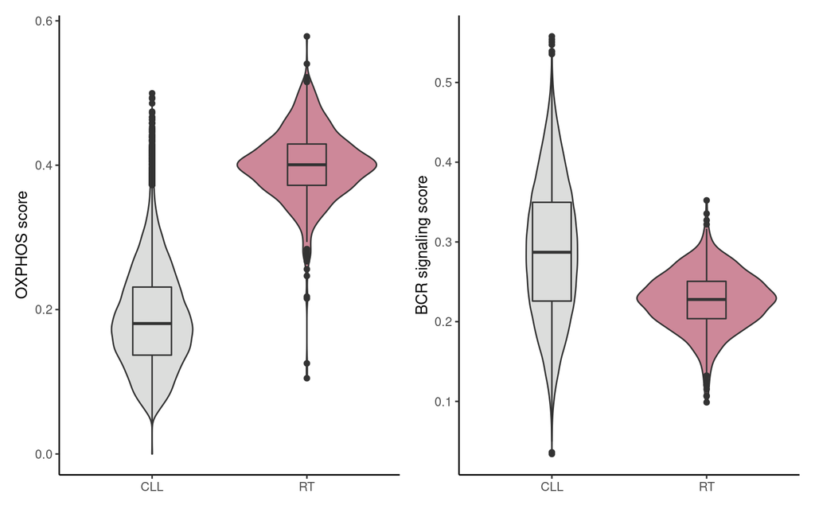

```r
# Violin plots + boxplots
training_set <- subset(seurat, is_training == "training")
training_df <- training_set@meta.data[, c("is_rt", "oxphos_score_UCell", "bcr_score_UCell")]
vln_plot_oxphos <- training_df %>%
  ggplot(aes(is_rt, oxphos_score_UCell, fill = is_rt)) +
    geom_violin() +
    geom_boxplot(width = 0.25) +
    scale_fill_manual(values = cols_rt) +
    ylab("OXPHOS score") +
    theme_classic() +
    theme(legend.position = "none", axis.title.x = element_blank())
vln_plot_bcr <- training_df %>%
  ggplot(aes(is_rt, bcr_score_UCell, fill = is_rt)) +
    geom_violin() +
    geom_boxplot(width = 0.25) +
    scale_fill_manual(values = cols_rt) +
    ylab("BCR signaling score") +
    theme_classic() +
    theme(legend.position = "none", axis.title.x = element_blank())
vln_plot_oxphos | vln_plot_bcr
```

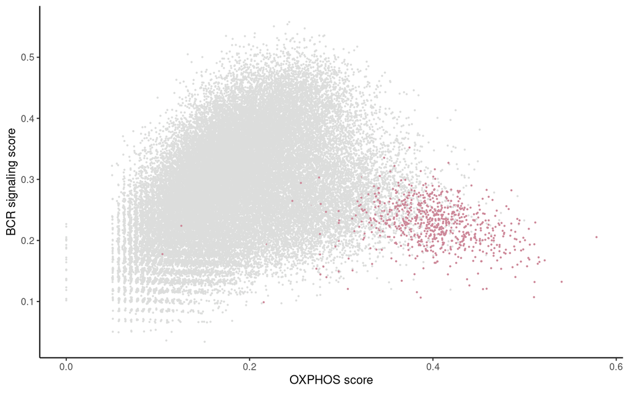

```r
# Scatter plot
scatter_plot <- training_df %>%
  ggplot(aes(oxphos_score_UCell, bcr_score_UCell, color = is_rt)) +
    geom_point(size = 0.25) +
    scale_color_manual(values = cols_rt) +
    labs(x = "OXPHOS score", y = "BCR signaling score") +
    theme_classic() +
    theme(legend.position = "none")
scatter_plot
```

# 3 Train models

```r
training_df$is_rt <- ifelse(training_df$is_rt == "RT", 1, 0)
oxphos_fit <- glm(is_rt ~ oxphos_score_UCell, data = training_df, family = "binomial")
bcr_fit <- glm(is_rt ~ bcr_score_UCell, data = training_df, family = "binomial")
oxphos_bcr_fit <- glm(is_rt ~ ., data = training_df, family = "binomial")
summary(oxphos_fit)
```

```
##
## Call:
## glm(formula = is_rt ~ oxphos_score_UCell, family = "binomial",
##     data = training_df)
##
## Deviance Residuals:
##     Min       1Q   Median       3Q      Max
## -3.1263  -0.0354  -0.0111  -0.0040   5.1130
##
## Coefficients:
##                    Estimate Std. Error z value Pr(>|z|)
## (Intercept)        -17.8443     0.4474  -39.88   <2e-16 ***
## oxphos_score_UCell  45.4822     1.2245   37.14   <2e-16 ***
## ---
## Signif. codes:  0 '***' 0.001 '**' 0.01 '*' 0.05 '.' 0.1 ' ' 1
##
## (Dispersion parameter for binomial family taken to be 1)
##
##     Null deviance: 7376.4  on 42363  degrees of freedom
## Residual deviance: 2305.0  on 42362  degrees of freedom
## AIC: 2309
##
## Number of Fisher Scoring iterations: 10
```

```r
summary(bcr_fit)
```

```
##
## Call:
## glm(formula = is_rt ~ bcr_score_UCell, family = "binomial", data = training_df)
##
## Deviance Residuals:
##     Min       1Q   Median       3Q      Max
## -0.5210  -0.2142  -0.1597  -0.1177   3.1501
##
## Coefficients:
##                 Estimate Std. Error z value Pr(>|z|)
## (Intercept)      -1.6049     0.1192  -13.46   <2e-16 ***
## bcr_score_UCell  -9.5118     0.4968  -19.15   <2e-16 ***
## ---
## Signif. codes:  0 '***' 0.001 '**' 0.01 '*' 0.05 '.' 0.1 ' ' 1
##
## (Dispersion parameter for binomial family taken to be 1)
##
##     Null deviance: 7376.4  on 42363  degrees of freedom
## Residual deviance: 6969.6  on 42362  degrees of freedom
## AIC: 6973.6
##
## Number of Fisher Scoring iterations: 7
```

```r
summary(oxphos_bcr_fit)
```

```
##
## Call:
## glm(formula = is_rt ~ ., family = "binomial", data = training_df)
##
## Deviance Residuals:
##     Min       1Q   Median       3Q      Max
## -3.1254  -0.0252  -0.0095  -0.0047   4.6267
##
## Coefficients:
##                    Estimate Std. Error z value Pr(>|z|)
## (Intercept)        -11.4424     0.5072  -22.56   <2e-16 ***
## oxphos_score_UCell  42.1255     1.2327   34.17   <2e-16 ***
## bcr_score_UCell    -20.3072     1.3653  -14.87   <2e-16 ***
## ---
## Signif. codes:  0 '***' 0.001 '**' 0.01 '*' 0.05 '.' 0.1 ' ' 1
##
## (Dispersion parameter for binomial family taken to be 1)
##
##     Null deviance: 7376.4  on 42363  degrees of freedom
## Residual deviance: 2010.7  on 42361  degrees of freedom
## AIC: 2016.7
##
## Number of Fisher Scoring iterations: 10
```

# 4 Test models

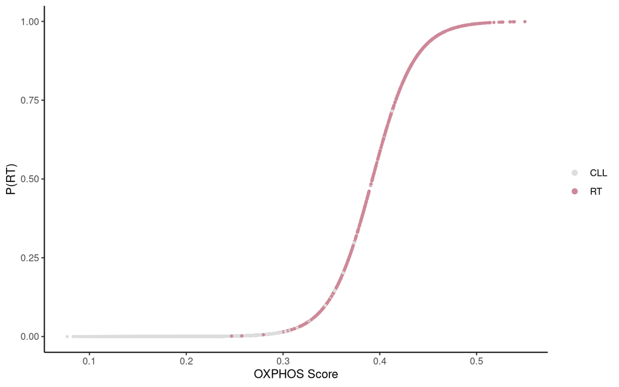

```r
# Predict probabilities on test set
test_set <- subset(seurat, is_training != "training")
test_df <- test_set@meta.data[, c("is_rt", "oxphos_score_UCell", "bcr_score_UCell")]
test_df$is_rt <- ifelse(test_df$is_rt == "RT", 1, 0)
test_df$probabilities_oxhpos <- predict(oxphos_fit,newdata = test_df, type = "response")
test_df$probabilities_bcr <- predict(bcr_fit, newdata = test_df, type = "response")
test_df$probabilities_oxhpos_bcr <- predict(oxphos_bcr_fit, newdata = test_df, type = "response")


# Plot sigmoidal curves
sigm_oxphos <- test_df %>%
  mutate(is_rt = ifelse(is_rt == 1, "RT", "CLL")) %>%
  ggplot(aes(oxphos_score_UCell, probabilities_oxhpos, color = is_rt)) +
    geom_point(size = 0.75) +
    scale_color_manual(values = cols_rt) +
    labs(x = "OXPHOS Score", y = "P(RT)") +
    theme_classic() +
    theme(legend.title = element_blank()) +
    guides(color = guide_legend(override.aes = list(size = 2)))
sigm_oxphos
```

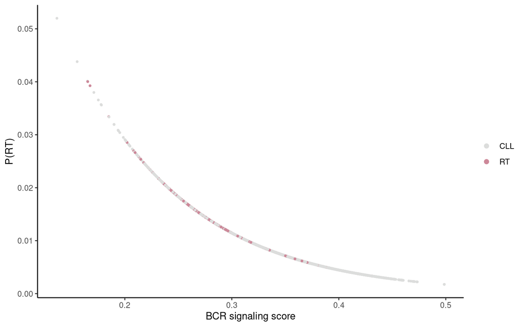

```r
sigm_bcr <- test_df %>%
  mutate(is_rt = ifelse(is_rt == 1, "RT", "CLL")) %>%
  ggplot(aes(bcr_score_UCell, probabilities_bcr, color = is_rt)) +
    geom_point(size = 0.75) +
    scale_color_manual(values = cols_rt) +
    labs(x = "BCR signaling score", y = "P(RT)") +
    theme_classic() +
    theme(legend.title = element_blank()) +
    guides(color = guide_legend(override.aes = list(size = 2)))
sigm_bcr
```

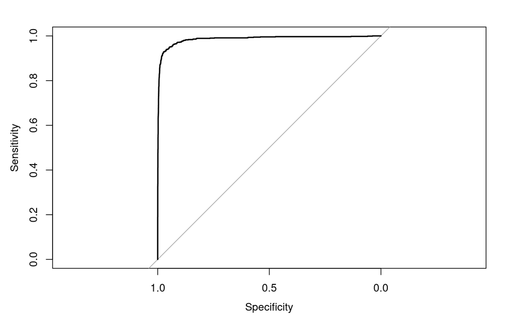

```r
# Area under the curve (AUC)
roc_oxphos <- pROC::roc(
  response = test_df$is_rt,
  predictor = test_df$probabilities_oxhpos
)
roc_bcr <- pROC::roc(
  response = test_df$is_rt,
  predictor = test_df$probabilities_bcr
)
roc_oxphos_bcr <- pROC::roc(
  response = test_df$is_rt,
  predictor = test_df$probabilities_oxhpos_bcr
)
plot(roc_oxphos)
```

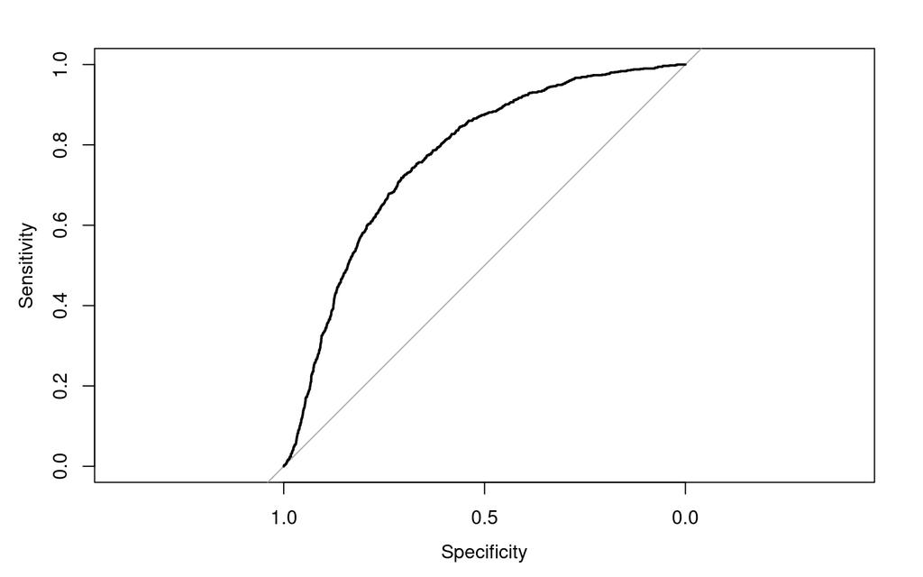

```r
plot(roc_bcr)
```

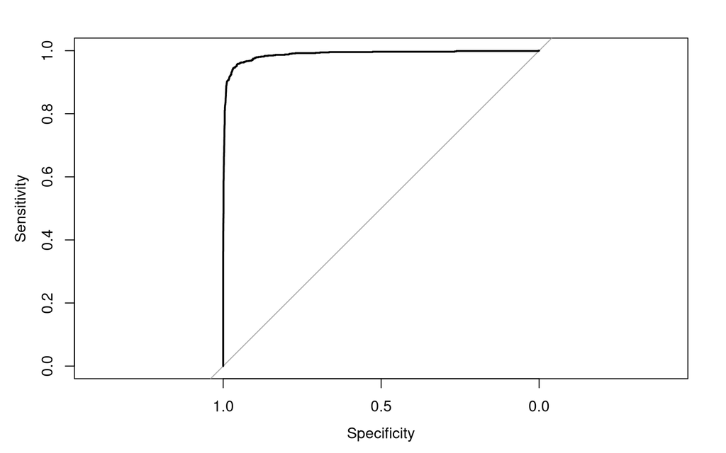

```r
plot(roc_oxphos_bcr)
```

```r
roc_oxphos$auc[1]
```

```
## [1] 0.9865286
```

```r
roc_bcr$auc[1]
```

```
## [1] 0.7669159
```

```r
roc_oxphos_bcr$auc[1]
```

```
## [1] 0.9886392
```

Of note, Receiver Operating Characteristic (ROC) curves do not take into account the intercept of the logistic regression model, which informs about the proportion of RT cases in the training set. Although the area under the ROC curves (AUROC) between OXPHOS and OXPHOS+BCR are almost identical, perhaps the probability values (P(RT)) are higher in one than in the other. Let us inspect this:

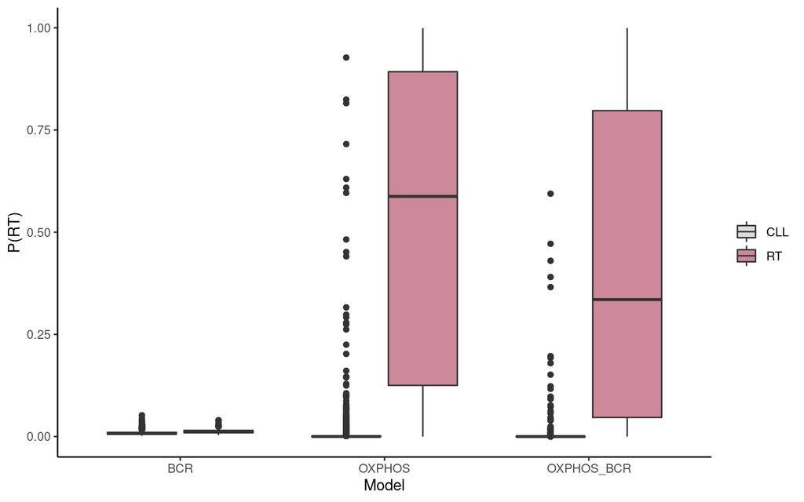

```r
df1 <- test_df[, c("is_rt", "oxphos_score_UCell", "bcr_score_UCell")]
dfs <- list(OXPHOS = df1, BCR = df1, OXPHOS_BCR = df1)
dfs$OXPHOS$probability_rt <- test_df$probabilities_oxhpos
dfs$BCR$probability_rt <- test_df$probabilities_bcr
dfs$OXPHOS_BCR$probability_rt <- test_df$probabilities_oxhpos_bcr
test_tidy_df <- bind_rows(dfs, .id = "model")
(box_plots <- test_tidy_df %>%
  mutate(is_rt = ifelse(is_rt == 1, "RT", "CLL")) %>%
  ggplot(aes(model, probability_rt, fill = is_rt)) +
    geom_boxplot() +
    scale_fill_manual(values = cols_rt) +
    labs(x = "Model", y = "P(RT)", fill = "") +
    theme_classic())
```

```r
summary(test_df$probabilities_oxhpos)
```

```
##      Min.   1st Qu.    Median      Mean   3rd Qu.      Max.
## 0.0000006 0.0000584 0.0002604 0.0846295 0.0020071 0.9992278
```

```r
summary(test_df$probabilities_bcr)
```

```
##     Min.  1st Qu.   Median     Mean  3rd Qu.     Max.
## 0.001748 0.006094 0.008185 0.009279 0.011302 0.051989
```

```r
summary(test_df$probabilities_oxhpos_bcr)
```

```
##      Min.   1st Qu.    Median      Mean   3rd Qu.      Max.
## 0.0000002 0.0000199 0.0000752 0.0660634 0.0004652 0.9993676
```

# 5 Save

```r
write_delim(training_df, path_to_save_training, delim = ";", col_names = TRUE)
write_delim(test_tidy_df, path_to_save_test, delim = ";", col_names = TRUE)
models <- list(
  OXPHOS = oxphos_fit,
  BCR = bcr_fit,
  OXPHOS_BCR = oxphos_bcr_fit
)
saveRDS(models, path_to_save_models)
```